# Deriving reproducible biomarkers from multi-site resting-state data: An Autism-based example - ScienceDirect

### 3.7. Inspecting discriminative connections

A connection between two regions is considered discriminative if its value helps diagnosing ASD from TC. To understand what is driving the best prediction pipeline, we extract its most discriminative connections as described in Section 2.7. Given that the 10-fold cross-validation yields 10 different atlases, we start by building a consensus atlas by taking all the regions with a DICE similarity score above 0.9. We obtain an atlas composed of 37 regions (see Fig. 6). These regions and the discriminative connections form the neurophenotypes. Note that discriminative connections should be interpreted with caution. Indeed, our study covers a wide range of age and diagnostic criteria. Additionally, predictive models cannot be interpreted as edge-level tests.

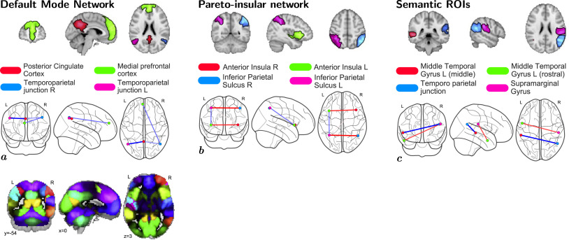

Fig. 6. *Significant non-zero connections in the predictive biomarkers distinguishing controls from* *[ASD](https://www.sciencedirect.com/topics/medicine-and-dentistry/atrial-septal-defect)* *patients.* Red connections are stronger in controls and blue connections are stronger in ASD patients. Subfigures *a*, *b*, and *c* reported intra-network difference. On the left is the consensus atlas obtained by selecting regions consistently extracted on 10 subsets of ABIDE. Colors are randomly assigned. Results obtained on other networks are shown in the appendices –Fig. Fig. D7.

*[Default Mode Network](https://www.sciencedirect.com/topics/medicine-and-dentistry/default-mode-network)* (Fig. 6a). We observe a lower connectivity between left and right [temporo-parietal junctions](https://www.sciencedirect.com/topics/medicine-and-dentistry/temporoparietal-junction). Both hypoconnectivity between regions on adolescent and adult patients (Cherkassky et al., 2006, Kennedy et al., 2006) and hyperconnectivity in children (Supekar et al., 2013) have been reported. Our findings are concordant with (Monk et al., 2009) that observed lower fronto-parietal connectivity and stronger connectivity between temporal ROIs.

*Pareto-insular network* (Fig. 6b). We observe interhemispheric hypoconnectivity between left and right anterior insulae, and left and right inferior [parietal lobes](https://www.sciencedirect.com/topics/medicine-and-dentistry/parietal-lobe). Those regions are part of a frontoparietal control network related to learning and memory (Iidaka et al., 2006). Such hypoconnectivity has already been widely evoked in ASD (Anderson et al., 2010, Di Martino et al., 2011) and previously found in the ABIDE dataset (Plitt et al., Ray et al., 2014). These ROIs also match anatomical regions of increased cortical density in ASD (Haar et al., 2014).

## 4. Discussion

We studied pipelines that extract neurophenotypes from aggregate R-fMRI datasets through the following steps: (1) region definition from R-fMRI, (2) extraction of regions activity time series (3) estimation of functional interactions between regions, and (4) construction of a discriminant model for brain-based diagnostic classification. The proposed pipelines can be built with the Nilearn neuroimaging-analysis software and the atlas computed with MSDL is available for download.<sup>13</sup> We have demonstrated that they can successfully predict diagnostic status across new acquisition sites in a real-world situation, a large [Autism](https://www.sciencedirect.com/topics/medicine-and-dentistry/pervasive-developmental-disorder) database. This validation with a leave-one-site-out cross-validation strategy reduces the risk of overfitting data from a single site, as opposed to the commonly used leave-one-subject-out validation approach (Nielsen et al., 2013). It enabled us to measure the impact of methodological choices on prediction. In the ABIDE dataset, this approach classified the label of autism versus control with an accuracy of 67% – a rate superior to prior work using the larger ABIDE sample.

The heterogeneity of weakly-controlled datasets formed by aggregation of multiple sites poses great challenges to develop brain-based classifiers for [psychiatric illnesses](https://www.sciencedirect.com/topics/neuroscience/psychopathology). Among those most commonly cited are: (i) the many sources of uncontrolled variation that can arise across studies and sites (e.g. scanner type, pulse sequence, recruitment strategies, sample composition), (ii) the potential for developing classifiers that are reflective of only the largest sites included, and (iii) the danger of extracting biomarkers that will be useful only on sites included in the training sample.

Counter to these concerns, our results demonstrated the feasibility of using weakly-controlled heterogeneous datasets to identify imaging biomarkers that are robust to differences among sites. Indeed, our prediction accuracy of 67% is the highest reported to-date on the whole ABIDE dataset (compared to 60% in Nielsen et al.), though better prediction has been reported on curated more homogeneous subsets (Plitt et al.; Chen et al., 2011). Importantly, we found that increasing sample size helped tackling heterogeneity as inter-site prediction accuracy approached that of intra-site prediction. This undoubtedly increases the perceived value that can be derived from aggregate datasets, such as the ABIDE and the ADHD-200 (Consortium et al.).

Our results suggest directions to improve prediction accuracy. First, more data is needed to optimize the classifier. Indeed, our experiments show that with a training set of 690 participants aggregated across multiple sites (80% of 871 available subjects), the pipelines have not reached their optimal performance. Second, a broader diversity of data will be needed to more definitively assess prediction for sites not included in the training set. Both of these needs motivate more data sharing.

Methodologically, our systematic comparison of choices in the pipeline steps can give indications to establish standard processing pipelines. Given that processing pipelines differ greatly between studies (Carp, 2012), comparing data-analysis methods is challenging. On the ABIDE dataset, we found that a good choice of processing steps can strongly improve prediction accuracy. In particular, the choice of regions is most important. We found that extracting these regions with MSDL gives best results. However, the benefit of this method is not always clear cut – on small datasets, references atlases are also good performers. For the rest of the pipeline, tangent embedding and ℓ<sub>2</sub>-regularized classifier are overall the best choice to maximize prediction accuracy.

While the primary goals of this study were methodological, it is worth noting that biomarkers identified were largely consistent with the current understanding of the neural basis of [ASD](https://www.sciencedirect.com/topics/medicine-and-dentistry/atrial-septal-defect). The most informative features to predict ASD concentrated in the intrinsic [functional connectivity](https://www.sciencedirect.com/topics/medicine-and-dentistry/functional-connectivity) of three main functional systems: the default-mode, parieto-insular, and language networks, previously involved in ASD (Vissers et al., 2012, Rane et al., 2015, Hernandez et al., 2015). Specifically, decreased homotopic connectivity between [temporo-parietal junction](https://www.sciencedirect.com/topics/medicine-and-dentistry/temporoparietal-junction), insula and inferior [parietal lobes](https://www.sciencedirect.com/topics/medicine-and-dentistry/parietal-lobe) appeared to characterize ASD. Decreases in homotopic functional connectivity have been previously reported in R-fMRI studies with moderately (Anderson et al., 2010, Dinstein et al., 2011) or large samples such as ABIDE (Di Martino et al., 2014). Here our findings point toward a set of inter-hemispheric connections involving heteromodal [association cortex](https://www.sciencedirect.com/topics/medicine-and-dentistry/association-cortex) subserving [social cognition](https://www.sciencedirect.com/topics/medicine-and-dentistry/social-cognition) (i.e. temporo-parietal junction (Saxe and Kanwisher, 2003)), and cognitive control (anterior insula and right [inferior parietal cortex](https://www.sciencedirect.com/topics/medicine-and-dentistry/inferior-parietal-cortex) (Menon and Uddin, 2010)), commonly affected in ASD (Anderson et al., 2010, Di Martino et al., 2011, Plitt et al.,, Ray et al., 2014). Limitations of our biomarkers may arise from the heterogeneity of ASD as a neuropsychiatric disorder (Geschwind and Levitt, 2007).

Beyond forming a neural correlate of the disorder, predictive biomarkers can help define diagnosis subgroups – the next logical endeavor in classification studies (Loth et al., 2016).

As a psychiatric study, the present work has a number of limitations. First, although composed of samples from geographically distinct sites, the representativeness of the ABIDE sample has not been established. As such, the features identified may be biased and necessitate further replication; though their consistency with prior findings alleviates this concern to some degree. Further work calls for characterizing this prediction pipeline on more participants (e.g. ABIDE (II) and different pathologies (e.g. ADHD-200 dataset). Second, while the present work primarily relied on prediction accuracy to assess the classifiers derived, a variety of alternative measures exist (e.g. sensitivity, specificity, J-statistic). This decision was largely motivated to facilitate comparison of our findings with those from prior studies using ABIDE, which most frequently used prediction accuracy. Depending on the specific application for a classifier, the prediction metric to optimize may vary. For example screening tools would need to favor sensitivity over accuracy or specificity; in contrast with medical diagnostic tests that require specificity over sensitivity or accuracy (Castellanos et al., 2013). The versatility of the pipeline studied allows us to maximize either of these scores depending on the experimenter's needs. Finally, while the present work focused on the ABIDE dataset, it is likely that its findings regarding optimal pipeline decisions will carry over to other aggregate samples, as well as more homogeneous samples. With that said, future applications will be required to verify this point.

In sum, we experimented with a large number of different pipelines and parametrizations on the task of predicting ASD diagnosis on the ABIDE dataset. From an extensive study of the results, we have found that R-fMRI from a large amount of participants sampled from many different sites could lead to functional-connectivity biomarkers of ASD that are robust, including to inter-site variability. Their predictive power markedly increases with the number of participants included. This increase holds promise for optimal biomarkers forming good probes of disorders.

## Acknowledgments

We acknowledge funding from the NiConnect project (ANR-11-BINF-0004 NiConnect) and the SUBSample project from the DIGITEO Institute, France. The effort of Adriana Di Martino was partially supported by the NIMH grant 1R21MH107045-01A1. Support for M.P. Milham made possible by [gifts](https://www.sciencedirect.com/topics/medicine-and-dentistry/gamete-intrafallopian-transfer) to the Child Mind Institute from Phyllis Green, Randolph Cowen, and Joseph Healey. Finally, we thank the anonymous reviewers for their feedback, as well as all sites and investigators who have worked to share their data through ABIDE.

## Appendix A. Supplementary information

[Download : Download Acrobat PDF file (1MB)](https://ars.els-cdn.com/content/image/1-s2.0-S1053811916305924-mmc1.pdf)

Supplementary Material

## References

**Abraham et al., 2013**

Abraham, A., Dohmatob, E., Thirion, B., Samaras, D., Varoquaux, G., Extracting brain regions from rest fMRI with Total-Variation constrained dictionary learning. In: MICCAI, 2013, p. 607.

Google Scholar

**Anderson et al., 2010**

J.S. Anderson, T.J. Druzgal, A. Froehlich, M.B. DuBray, N. Lange, A.L. Alexander, T. Abildskov, J.A. Nielsen, A.N. Cariello, J.R. Cooperrider, *et al.*

**Decreased interhemispheric functional connectivity in autism**

Cereb. Cortex (2010)

(bhq190)

Google Scholar

**Anderson et al., 2011**

J.S. Anderson, J.A. Nielsen, A.L. Froehlich, M.B. DuBray, T.J. Druzgal, A.N. Cariello, J.R. Cooperrider, B.A. Zielinski, C. Ravichandran, P.T. Fletcher, *et al.*

**Functional connectivity magnetic resonance imaging classification of autism**

Brain, 134 (12) (2011), pp. 3742-3754

[CrossRef](https://doi.org/10.1093/brain/awr263)[View Record in Scopus](https://www.scopus.com/inward/record.url?eid=2-s2.0-84872178888&partnerID=10&rel=R3.0.0)Google Scholar

**Anderson et al.,**

Anderson, J.S., Nielsen, J.A., Ferguson, M.A., Burback, M.C., Cox, E.T., Dai, L., Gerig, G., Edgin, J.O., Korenberg, J.R., Abnormal brain synchrony in down syndrome, NeuroImage: Clinical, 2013.

Google Scholar

**Avants et al., 2009**

B.B. Avants, N. Tustison, G. Song

**Advanced normalization tools (ants)**

Insight J, 2 (2009), pp. 1-35

[View Record in Scopus](https://www.scopus.com/inward/record.url?eid=2-s2.0-84879726562&partnerID=10&rel=R3.0.0)[Google Scholar](https://scholar.google.com/scholar?q=Advanced%20normalization%20tools)

**Beckmann and Smith, 2004**

C.F. Beckmann, S.M. Smith

**Probabilistic independent component analysis for functional magnetic resonance imaging**

Trans. Med Im., 23 (2004), pp. 137-152

[View Record in Scopus](https://www.scopus.com/inward/record.url?eid=2-s2.0-1342324773&partnerID=10&rel=R3.0.0)Google Scholar

**Behzadi et al., 2007**

Y. Behzadi, K. Restom, J. Liau, T. Liu

**A component based noise correction method (CompCor) for bold and perfusion based fMRI**

Neuroimage, 37 (2007), p. 90

[Article](https://www.sciencedirect.com/science/article/pii/S1053811907003837)[Download PDF](https://www.sciencedirect.com/science/article/pii/S1053811907003837/pdfft?md5=34fadd7c10e5273204a2799958362455&pid=1-s2.0-S1053811907003837-main.pdf)[View Record in Scopus](https://www.scopus.com/inward/record.url?eid=2-s2.0-34447551672&partnerID=10&rel=R3.0.0)[Google Scholar](https://scholar.google.com/scholar?q=A%20component%20based%20noise%20correction%20method%20%20for%20bold%20and%20perfusion%20based%20fMRI)

**Button et al., 2013**

K.S. Button, J.P. Ioannidis, C. Mokrysz, B.A. Nosek, J. Flint, E.S. Robinson, M.R. Munafò

**Power failure: why small sample size undermines the reliability of neuroscience**

Nat. Rev. Neurosci., 14 (5) (2013), pp. 365-376

[CrossRef](https://doi.org/10.1038/nrn3475)[View Record in Scopus](https://www.scopus.com/inward/record.url?eid=2-s2.0-84876665206&partnerID=10&rel=R3.0.0)Google Scholar

**Calhoun et al., 2001**

V.D. Calhoun, T. Adali, G.D. Pearlson, J.J. Pekar

**A method for making group inferences from fMRI data using independent component analysis**

Hum. Brain Mapp., 14 (2001), p. 140

[CrossRef](https://doi.org/10.1002/hbm.1048)[View Record in Scopus](https://www.scopus.com/inward/record.url?eid=2-s2.0-0034753663&partnerID=10&rel=R3.0.0)Google Scholar

**Calhoun et al.,**

Calhoun, V.D., Sui, J., Kiehl, K., Turner, J., Allen, E., Pearlson, G., Exploring the psychosis functional connectome: aberrant intrinsic networks in schizophrenia and bipolar disorder, Frontiers in psychiatry 2, 2011.

Google Scholar

**Carp, 2012**

J. Carp

**The secret lives of experiments: methods reporting in the fMRI literature**

Neuroimage, 63 (1) (2012), pp. 289-300

[Article](https://www.sciencedirect.com/science/article/pii/S1053811912007057)[Download PDF](https://www.sciencedirect.com/science/article/pii/S1053811912007057/pdfft?md5=9d9436880f055b3f0c25ee780dfd5d9c&pid=1-s2.0-S1053811912007057-main.pdf)[View Record in Scopus](https://www.scopus.com/inward/record.url?eid=2-s2.0-84864409471&partnerID=10&rel=R3.0.0)[Google Scholar](https://scholar.google.com/scholar_lookup?title=The%20secret%20lives%20of%20experiments%3A%20methods%20reporting%20in%20the%20fMRI%20literature&publication_year=2012&author=J.%20Carp)

**Castellanos et al., 2013**

F.X. Castellanos, A. Di Martino, R.C. Craddock, A.D. Mehta, M.P. Milham

**Clinical applications of the functional connectome**

Neuroimage, 80 (2013), pp. 527-540

[Article](https://www.sciencedirect.com/science/article/pii/S1053811913004308)[Download PDF](https://www.sciencedirect.com/science/article/pii/S1053811913004308/pdfft?md5=de777bc22f7bf23bf751e7b855e80d54&pid=1-s2.0-S1053811913004308-main.pdf)[View Record in Scopus](https://www.scopus.com/inward/record.url?eid=2-s2.0-84880326169&partnerID=10&rel=R3.0.0)Google Scholar

**Chen et al., 2011**

G. Chen, B.D. Ward, C. Xie, W. Li, Z. Wu, J.L. Jones, M. Franczak, P. Antuono, S.-J. Li

**Classification of alzheimer disease, mild cognitive impairment, and normal cognitive status with large-scale network analysis based on resting-state functional mr imaging**

Radiology, 259 (1) (2011), pp. 213-221

[CrossRef](https://doi.org/10.1148/radiol.10100734)[View Record in Scopus](https://www.scopus.com/inward/record.url?eid=2-s2.0-79953010204&partnerID=10&rel=R3.0.0)Google Scholar

**Chen et al., 2011**

Chen, C.P., Keown, C.L., Jahedi, A., Nair, A., Pflieger, M.E., Bailey, B.A., Müller, R.-A., Diagnostic classification of intrinsic functional connectivity highlights somatosensory, default mode, and visual regions in autism, NeuroImage: Clinical, 2015.

Google Scholar

**Cherkassky et al., 2006**

V.L. Cherkassky, R.K. Kana, T.A. Keller, M.A. Just

**Functional connectivity in a baseline resting-state network in autism**

Neuroreport, 17 (16) (2006), pp. 1687-1690

[CrossRef](https://doi.org/10.1097/01.wnr.0000239956.45448.4c)[View Record in Scopus](https://www.scopus.com/inward/record.url?eid=2-s2.0-33750319668&partnerID=10&rel=R3.0.0)Google Scholar

**Consortium,**

Consortium, A., et al., The adhd-200 consortium: a model to advance the translational potential of neuroimaging in clinical neuroscience, Frontiers in systems neuroscience 6, 2012.

Google Scholar

**Craddock et al.,**

R. Craddock, P. Holtzheimer III, X. Hu, H. Mayberg

**Disease state prediction from resting state functional connectivity**

Magn. Reson. Med., 62 (2009), p. 1619

[CrossRef](https://doi.org/10.1002/mrm.22159)[View Record in Scopus](https://www.scopus.com/inward/record.url?eid=2-s2.0-73149109077&partnerID=10&rel=R3.0.0)Google Scholar

**Craddock et al., 2012**

R.C. Craddock, G.A. James, P.E. Holtzheimer, X.P. Hu, H.S. Mayberg

**A whole brain fMRI atlas generated via spatially constrained spectral clustering**

Human. Brain Mapp., 33 (8) (2012), pp. 1914-1928

[CrossRef](https://doi.org/10.1002/hbm.21333)[View Record in Scopus](https://www.scopus.com/inward/record.url?eid=2-s2.0-84863882574&partnerID=10&rel=R3.0.0)Google Scholar

**Craddock et al., 2013**

R.C. Craddock, S. Jbabdi, C.-G. Yan, J.T. Vogelstein, F.X. Castellanos, A. Di Martino, C. Kelly, K. Heberlein, S. Colcombe, M.P. Milham

**Imaging human connectomes at the macroscale**

Nat. Methods, 10 (6) (2013), pp. 524-539

[CrossRef](https://doi.org/10.1038/nmeth.2482)[View Record in Scopus](https://www.scopus.com/inward/record.url?eid=2-s2.0-84880814671&partnerID=10&rel=R3.0.0)Google Scholar

**Craddock et al., 2013**

Craddock, C., Sikka, S., Cheung, B., Khanuja, R., Ghosh, S., Yan, C., Li, Q., Lurie, D., Vogelstein, J., Burns, R., et al., Towards automated analysis of connectomes: The configurable pipeline for the analysis of connectomes (c-pac), Front Neuroinform 42, 2013.

Google Scholar

**Desikan et al., 2006**

R.S. Desikan, F. Ségonne, B. Fischl, B.T. Quinn, B.C. Dickerson, D. Blacker, R.L. Buckner, A.M. Dale, *et al.*

**An automated labeling system for subdividing the human cerebral cortex on MRI scans into gyral based regions of interest**

Neuroimage, 31 (2006), p. 968

[Article](https://www.sciencedirect.com/science/article/pii/S1053811906000437)[Download PDF](https://www.sciencedirect.com/science/article/pii/S1053811906000437/pdfft?md5=360cfc003234b42f060f6ba67c186b17&pid=1-s2.0-S1053811906000437-main.pdf)[View Record in Scopus](https://www.scopus.com/inward/record.url?eid=2-s2.0-33746932485&partnerID=10&rel=R3.0.0)Google Scholar

**Desmond and Glover, 2002**

J.E. Desmond, G.H. Glover

**Estimating sample size in functional MRI (fMRI) neuroimaging studies: statistical power analyses**

J. Neurosci. Methods, 118 (2) (2002), pp. 115-128

[Article](https://www.sciencedirect.com/science/article/pii/S0165027002001218)[Download PDF](https://www.sciencedirect.com/science/article/pii/S0165027002001218/pdfft?md5=0b69016506672b784c164795a0b22341&pid=1-s2.0-S0165027002001218-main.pdf)[View Record in Scopus](https://www.scopus.com/inward/record.url?eid=2-s2.0-0037200722&partnerID=10&rel=R3.0.0)[Google Scholar](https://scholar.google.com/scholar?q=Estimating%20sample%20size%20in%20functional%20MRI%20%20neuroimaging%20studies:%20statistical%20power%20analyses)

**Di Martino et al., 2011**

A. Di Martino, C. Kelly, R. Grzadzinski, X.-N. Zuo, M. Mennes, M.A. Mairena, C. Lord, F.X. Castellanos, M.P. Milham

**Aberrant striatal functional connectivity in children with autism**

Biol. Psychiatry, 69 (9) (2011), pp. 847-856

[Article](https://www.sciencedirect.com/science/article/pii/S0006322310011625)[Download PDF](https://www.sciencedirect.com/science/article/pii/S0006322310011625/pdfft?md5=ff3be84b6d1ba5531b31675c70fd2c53&pid=1-s2.0-S0006322310011625-main.pdf)[View Record in Scopus](https://www.scopus.com/inward/record.url?eid=2-s2.0-79954947943&partnerID=10&rel=R3.0.0)Google Scholar

**Di Martino et al., 2014**

A. Di Martino, C.-G. Yan, Q. Li, E. Denio, F.X. Castellanos, K. Alaerts, J.S. Anderson, M. Assaf, S.Y. Bookheimer, M. Dapretto, *et al.*

**The autism brain imaging data exchange: towards a large-scale evaluation of the intrinsic brain architecture in autism**

Mol. Psychiatry, 19 (6) (2014), pp. 659-667

[CrossRef](https://doi.org/10.1038/mp.2013.78)[View Record in Scopus](https://www.scopus.com/inward/record.url?eid=2-s2.0-84901284227&partnerID=10&rel=R3.0.0)Google Scholar

**Dinstein et al., 2011**

I. Dinstein, K. Pierce, L. Eyler, S. Solso, R. Malach, M. Behrmann, E. Courchesne

**Disrupted neural synchronization in toddlers with autism**

Neuron, 70 (6) (2011), pp. 1218-1225

[Article](https://www.sciencedirect.com/science/article/pii/S0896627311003722)[Download PDF](https://www.sciencedirect.com/science/article/pii/S0896627311003722/pdfft?md5=026524490bd0134edc67138dbcda5923&pid=1-s2.0-S0896627311003722-main.pdf)[View Record in Scopus](https://www.scopus.com/inward/record.url?eid=2-s2.0-79959323867&partnerID=10&rel=R3.0.0)Google Scholar

**Dosenbach et al., 2010**

N.U. Dosenbach, B. Nardos, A.L. Cohen, D.A. Fair, J.D. Power, J.A. Church, S.M. Nelson, G.S. Wig, A.C. Vogel, C.N. Lessov-Schlaggar, *et al.*

**Prediction of individual brain maturity using fMRI**

Science, 329 (5997) (2010), pp. 1358-1361

[CrossRef](https://doi.org/10.1126/science.1194144)[View Record in Scopus](https://www.scopus.com/inward/record.url?eid=2-s2.0-77956517416&partnerID=10&rel=R3.0.0)Google Scholar

**Eickhoff et al., 2015**

S.B. Eickhoff, B. Thirion, G. Varoquaux, D. Bzdok

**Connectivity-based parcellation: critique and implications**

Human. Brain Mapp., 36 (12) (2015), pp. 4771-4792

[CrossRef](https://doi.org/10.1002/hbm.22933)[View Record in Scopus](https://www.scopus.com/inward/record.url?eid=2-s2.0-84956574733&partnerID=10&rel=R3.0.0)Google Scholar

**Fair et al.,**

Fair, D.A., Nigg, J.T., Iyer, Bathula, S., Mills, D.K.L., Dosenbach, N.U., Schlaggar, B.L., Mennes, M., Gutman, D., Bangaru, S. et al., Distinct neural signatures detected for ADHD subtypes after controlling for micro-movements in resting state functional connectivity MRI data, Frontiers in systems neuroscience 6, 2012.

Google Scholar

**Fox et al., 2005**

M. Fox, A. Snyder, J. Vincent, M. Corbetta, D. Van Essen, M. Raichle

**The human brain is intrinsically organized into dynamic, anticorrelated functional networks**

Proc. Ntl Acad. Sci., 102 (2005), p. 9673

[CrossRef](https://doi.org/10.1073/pnas.0504136102)[View Record in Scopus](https://www.scopus.com/inward/record.url?eid=2-s2.0-22144469412&partnerID=10&rel=R3.0.0)Google Scholar

**Friedman et al., 2008**

J. Friedman, T. Hastie, R. Tibshirani

**Sparse inverse covariance estimation with the graphical lasso**

Biostatistics, 9 (2008), p. 432

[CrossRef](https://doi.org/10.1093/biostatistics/kxm045)[View Record in Scopus](https://www.scopus.com/inward/record.url?eid=2-s2.0-45849134070&partnerID=10&rel=R3.0.0)[Google Scholar](https://scholar.google.com/scholar_lookup?title=Sparse%20inverse%20covariance%20estimation%20with%20the%20graphical%20lasso&publication_year=2008&author=J.%20Friedman&author=T.%20Hastie&author=R.%20Tibshirani)

**Friston et al., 1995**

K.J. Friston, A.P. Holmes, K.J. Worsley, J.-B. Poline, C. Frith, R.S.J. Frackowiak

**Statistical parametric maps in functional imaging: a general linear approach**

Hum. Brain Mapp. (1995), p. 189

[View Record in Scopus](https://www.scopus.com/inward/record.url?eid=2-s2.0-79954422763&partnerID=10&rel=R3.0.0)Google Scholar

**Garrity et al.,**

Garrity, A., Pearlson, G., McKiernan, K., Lloyd, D., Kiehl, K., Calhoun, V., Aberrant default mode functional connectivity in schizophrenia, Am. J. Psychiatry. 164, 2007.

Google Scholar

**Geschwind and Levitt, 2007**

D.H. Geschwind, P. Levitt

**Autism spectrum disorders: developmental disconnection syndromes**

Curr. Opin. Neurobiol., 17 (1) (2007), pp. 103-111

[Article](https://www.sciencedirect.com/science/article/pii/S0959438807000116)[Download PDF](https://www.sciencedirect.com/science/article/pii/S0959438807000116/pdfft?md5=4b9c80a1c58a19f19ef5e3f80e2c4c15&pid=1-s2.0-S0959438807000116-main.pdf)[View Record in Scopus](https://www.scopus.com/inward/record.url?eid=2-s2.0-33846921789&partnerID=10&rel=R3.0.0)[Google Scholar](https://scholar.google.com/scholar_lookup?title=Autism%20spectrum%20disorders%3A%20developmental%20disconnection%20syndromes&publication_year=2007&author=D.H.%20Geschwind&author=P.%20Levitt)

**Goutte et al., 1999**

C. Goutte, P. Toft, E. Rostrup, F.Å Nielsen, L.K. Hansen

**On clustering fMRI time series**

NeuroImage, 9 (3) (1999), pp. 298-310

[Article](https://www.sciencedirect.com/science/article/pii/S1053811998903913)[Download PDF](https://www.sciencedirect.com/science/article/pii/S1053811998903913/pdf?md5=f2bd3bacdc2357425428e941b13cb843&pid=1-s2.0-S1053811998903913-main.pdf)[View Record in Scopus](https://www.scopus.com/inward/record.url?eid=2-s2.0-0032796478&partnerID=10&rel=R3.0.0)Google Scholar

**Greicius, 2008**

M. Greicius

**Resting-state functional connectivity in neuropsychiatric disorders**

Curr. Opin. Neurol., 21 (2008), p. 424

[View Record in Scopus](https://www.scopus.com/inward/record.url?eid=2-s2.0-52049121840&partnerID=10&rel=R3.0.0)[Google Scholar](https://scholar.google.com/scholar_lookup?title=Resting-state%20functional%20connectivity%20in%20neuropsychiatric%20disorders&publication_year=2008&author=M.%20Greicius)

**Greicius et al., 2004**

M. Greicius, G. Srivastava, A. Reiss, V. Menon

**Default-mode network activity distinguishes Alzheimer's disease from healthy aging: evidence from functional MRI**

Proc. Natl. Acad. Sci., 101 (2004), p. 4637

[View Record in Scopus](https://www.scopus.com/inward/record.url?eid=2-s2.0-1842427969&partnerID=10&rel=R3.0.0)[Google Scholar](https://scholar.google.com/scholar?q=Default-mode%20network%20activity%20distinguishes%20Alzheimers%20disease%20from%20healthy%20aging:%20evidence%20from%20functional%20MRI)

**Haar et al., 2014**

S. Haar, S. Berman, M. Behrmann, I. Dinstein

**Anatomical abnormalities in autism?**

Cereb. Cortex (2014)

(bhu242)

[Google Scholar](https://scholar.google.com/scholar?q=Anatomical%20abnormalities%20in%20autism)

**Hernandez et al., 2015**

L.M. Hernandez, J.D. Rudie, S.A. Green, S. Bookheimer, M. Dapretto

**Neural signatures of autism spectrum disorders: insights into brain network dynamics**

Neuropsychopharmacology, 40 (1) (2015), pp. 171-189

[CrossRef](https://doi.org/10.1038/npp.2014.172)[View Record in Scopus](https://www.scopus.com/inward/record.url?eid=2-s2.0-84922343591&partnerID=10&rel=R3.0.0)Google Scholar

**Iidaka et al., 2006**

T. Iidaka, A. Matsumoto, J. Nogawa, Y. Yamamoto, N. Sadato

**Frontoparietal network involved in successful retrieval from episodic memory. spatial and temporal analyses using fMRI and ERP**

Cereb. Cortex, 16 (9) (2006), pp. 1349-1360

[CrossRef](https://doi.org/10.1093/cercor/bhl040)[View Record in Scopus](https://www.scopus.com/inward/record.url?eid=2-s2.0-33748328345&partnerID=10&rel=R3.0.0)Google Scholar

**Jafri et al., 2008**

M.J. Jafri, G.D. Pearlson, M. Stevens, V.D. Calhoun

**A method for functional network connectivity among spatially independent resting-state components in schizophrenia**

Neuroimage, 39 (4) (2008), pp. 1666-1681

[Article](https://www.sciencedirect.com/science/article/pii/S1053811907010282)[Download PDF](https://www.sciencedirect.com/science/article/pii/S1053811907010282/pdfft?md5=15c4eb166b952dc109f489be06fdfe0f&pid=1-s2.0-S1053811907010282-main.pdf)[View Record in Scopus](https://www.scopus.com/inward/record.url?eid=2-s2.0-38749089029&partnerID=10&rel=R3.0.0)Google Scholar

**Kapur et al., 2012**

S. Kapur, A.G. Phillips, T.R. Insel

**Why has it taken so long for biological psychiatry to develop clinical tests and what to do about it&quest**

Mol. Psychiatry, 17 (12) (2012), pp. 1174-1179

[CrossRef](https://doi.org/10.1038/mp.2012.105)[View Record in Scopus](https://www.scopus.com/inward/record.url?eid=2-s2.0-84870064521&partnerID=10&rel=R3.0.0)[Google Scholar](https://scholar.google.com/scholar?q=Why%20has%20it%20taken%20so%20long%20for%20biological%20psychiatry%20to%20develop%20clinical%20tests%20and%20what%20to%20do%20about%20itquest)

**Kelly et al., 2008**

A.C. Kelly, L.Q. Uddin, B.B. Biswal, F.X. Castellanos, M.P. Milham

**Competition between functional brain networks mediates behavioral variability**

Neuroimage, 39 (1) (2008), pp. 527-537

[Article](https://www.sciencedirect.com/science/article/pii/S1053811907007057)[Download PDF](https://www.sciencedirect.com/science/article/pii/S1053811907007057/pdfft?md5=1ed43aad85ea193021db98ad4dd2fc76&pid=1-s2.0-S1053811907007057-main.pdf)Google Scholar

**Kennedy et al., 2006**

D.P. Kennedy, E. Redcay, E. Courchesne

**Failing to deactivate: resting functional abnormalities in autism**

Proc. Natl. Acad. Sci., 103 (21) (2006), pp. 8275-8280

[CrossRef](https://doi.org/10.1073/pnas.0600674103)[View Record in Scopus](https://www.scopus.com/inward/record.url?eid=2-s2.0-33744487635&partnerID=10&rel=R3.0.0)Google Scholar

**Kleinhans et al., 2008**

N.M. Kleinhans, R.-A. Müller, D.N. Cohen, E. Courchesne

**Atypical functional lateralization of language in autism spectrum disorders**

Brain Res., 1221 (2008), pp. 115-125

[Article](https://www.sciencedirect.com/science/article/pii/S0006899308010767)[Download PDF](https://www.sciencedirect.com/science/article/pii/S0006899308010767/pdfft?md5=d01d863d0d08b8d84e890656773fdb5f&pid=1-s2.0-S0006899308010767-main.pdf)[View Record in Scopus](https://www.scopus.com/inward/record.url?eid=2-s2.0-46049114252&partnerID=10&rel=R3.0.0)Google Scholar

**Lashkari et al., 2010**

D. Lashkari, E. Vul, N. Kanwisher, P. Golland

**Discovering structure in the space of fMRI selectivity profiles**

NeuroImage, 50 (2010), p. 1085

[Article](https://www.sciencedirect.com/science/article/pii/S1053811909013950)[Download PDF](https://www.sciencedirect.com/science/article/pii/S1053811909013950/pdfft?md5=54800fb3076375d693ae4685e2d114f7&pid=1-s2.0-S1053811909013950-main.pdf)[View Record in Scopus](https://www.scopus.com/inward/record.url?eid=2-s2.0-77249084595&partnerID=10&rel=R3.0.0)Google Scholar

**Ledoit and Wolf, 2004**

O. Ledoit, M. Wolf

**A well-conditioned estimator for large-dimensional covariance matrices**

J. Multivar. Anal., 88 (2004), p. 365

[Article](https://www.sciencedirect.com/science/article/pii/S0047259X03000964)[Download PDF](https://www.sciencedirect.com/science/article/pii/S0047259X03000964/pdf?md5=ebb0bdf9f4cda444eb958e338078aa70&pid=1-s2.0-S0047259X03000964-main.pdf)[View Record in Scopus](https://www.scopus.com/inward/record.url?eid=2-s2.0-0346961488&partnerID=10&rel=R3.0.0)[Google Scholar](https://scholar.google.com/scholar_lookup?title=A%20well-conditioned%20estimator%20for%20large-dimensional%20covariance%20matrices&publication_year=2004&author=O.%20Ledoit&author=M.%20Wolf)

**Loth et al., 2016**

E. Loth, W. Spooren, L.M. Ham, M.B. Isaac, C. Auriche-Benichou, T. Banaschewski, S. Baron-Cohen, K. Broich, S. Bölte, T. Bourgeron, *et al.*

**Identification and validation of biomarkers for autism spectrum disorders**

Nat. Rev. Drug Discov., 15 (1) (2016), pp. 70-73

[View Record in Scopus](https://www.scopus.com/inward/record.url?eid=2-s2.0-84954461829&partnerID=10&rel=R3.0.0)Google Scholar

**Lund et al., 2005**

T.E. Lund, M.D. Nørgaard, E. Rostrup, J.B. Rowe, O.B. Paulson

**Motion or activity: their role in intra-and inter-subject variation in fMRI**

Neuroimage, 26 (3) (2005), pp. 960-964

[Article](https://www.sciencedirect.com/science/article/pii/S1053811905001266)[Download PDF](https://www.sciencedirect.com/science/article/pii/S1053811905001266/pdfft?md5=b8c712fef228a5a57775a651e5787f13&pid=1-s2.0-S1053811905001266-main.pdf)[View Record in Scopus](https://www.scopus.com/inward/record.url?eid=2-s2.0-20444456344&partnerID=10&rel=R3.0.0)Google Scholar

**Martinsson et al., 2011**

P. Martinsson, V. Rokhlin, M. Tygert

**A randomized algorithm for the decomposition of matrices**

Appl. Comput. Harmon. Anal., 30 (2011), p. 47

[Article](https://www.sciencedirect.com/science/article/pii/S1063520310000242)[Download PDF](https://www.sciencedirect.com/science/article/pii/S1063520310000242/pdf?md5=1d3ef625fe80ba3f9c5be7d110e56c38&pid=1-s2.0-S1063520310000242-main.pdf)[View Record in Scopus](https://www.scopus.com/inward/record.url?eid=2-s2.0-78649322960&partnerID=10&rel=R3.0.0)[Google Scholar](https://scholar.google.com/scholar_lookup?title=A%20randomized%20algorithm%20for%20the%20decomposition%20of%20matrices&publication_year=2011&author=P.%20Martinsson&author=V.%20Rokhlin&author=M.%20Tygert)

**Mennes et al., 2013**

M. Mennes, B.B. Biswal, F.X. Castellanos, M.P. Milham

**Making data sharing work: the fcp/indi experience**

Neuroimage, 82 (2013), pp. 683-691

[Article](https://www.sciencedirect.com/science/article/pii/S1053811912010671)[Download PDF](https://www.sciencedirect.com/science/article/pii/S1053811912010671/pdfft?md5=2e230f693fc3b4ac83989f4058cdae2f&pid=1-s2.0-S1053811912010671-main.pdf)[View Record in Scopus](https://www.scopus.com/inward/record.url?eid=2-s2.0-84883448855&partnerID=10&rel=R3.0.0)[Google Scholar](https://scholar.google.com/scholar?q=Making%20data%20sharing%20work:%20the%20fcpindi%20experience)

**Menon and Uddin, 2010**

V. Menon, L.Q. Uddin

**Saliency, switching, attention and control: a network model of insula function**

Brain Struct. Funct., 214 (5–6) (2010), pp. 655-667

[CrossRef](https://doi.org/10.1007/s00429-010-0262-0)[View Record in Scopus](https://www.scopus.com/inward/record.url?eid=2-s2.0-85027950875&partnerID=10&rel=R3.0.0)Google Scholar

**Monk et al., 2009**

C.S. Monk, S.J. Peltier, J.L. Wiggins, S.-J. Weng, M. Carrasco, S. Risi, C. Lord

**Abnormalities of intrinsic functional connectivity in autism spectrum disorders**

Neuroimage, 47 (2) (2009), pp. 764-772

[Article](https://www.sciencedirect.com/science/article/pii/S1053811909004327)[Download PDF](https://www.sciencedirect.com/science/article/pii/S1053811909004327/pdfft?md5=2e7bddfdb66f20a730c9e0d954401a45&pid=1-s2.0-S1053811909004327-main.pdf)[View Record in Scopus](https://www.scopus.com/inward/record.url?eid=2-s2.0-67349087393&partnerID=10&rel=R3.0.0)Google Scholar

**Murphy and Garavan, 2004**

K. Murphy, H. Garavan

**An empirical investigation into the number of subjects required for an event-related fmri study**

Neuroimage, 22 (2) (2004), pp. 879-885

[Article](https://www.sciencedirect.com/science/article/pii/S1053811904000977)[Download PDF](https://www.sciencedirect.com/science/article/pii/S1053811904000977/pdfft?md5=65fd8d8e273afa52d22eb8d099291d2c&pid=1-s2.0-S1053811904000977-main.pdf)[View Record in Scopus](https://www.scopus.com/inward/record.url?eid=2-s2.0-2942524074&partnerID=10&rel=R3.0.0)Google Scholar

**Ng et al., 2011**

Ng, B., Dressler, M., Varoquaux, G., Poline, J.B., Greicius, M., Thirion, B., Transport on riemannian manifold for functional connectivity-based classification. In: Medical Image Computing and Computer-Assisted Intervention–MICCAI 2014, Springer International Publishing, 2014, pp. 405–412.

Google Scholar

**Nielsen et al.,**

Nielsen, J.A., Zielinski, B.A., Fletcher, P.T., Alexander, A.L., Lange, N., Bigler, E.D., Lainhart, J.E., Anderson, J.S., Multisite functional connectivity MRI classification of autism: ABIDE results, Frontiers in human neuroscience 7, 2013.

Google Scholar

**Pedregosa et al., 2011**

F. Pedregosa, G. Varoquaux, A. Gramfort, V. Michel, *et al.*

**Scikit-learn: machine learning in python**

J. Mach. Learn. Res., 12 (2011), p. 2825

[View Record in Scopus](https://www.scopus.com/inward/record.url?eid=2-s2.0-80555140075&partnerID=10&rel=R3.0.0)[Google Scholar](https://scholar.google.com/scholar_lookup?title=Scikit-learn%3A%20machine%20learning%20in%20python&publication_year=2011&author=F.%20Pedregosa&author=G.%20Varoquaux&author=A.%20Gramfort&author=V.%20Michel)

**Plitt et al.,**

Plitt, M., Barnes, K.A., Martin, A. Functional connectivity classification of autism identifies highly predictive brain features but falls short of biomarker standards, NeuroImage: Clinical, 2015.

Google Scholar

**Rane et al., 2015**

P. Rane, D. Cochran, S.M. Hodge, C. Haselgrove, D.N. Kennedy, J.A. Frazier

**Connectivity in autism: a review of mri connectivity studies**

Harv. Rev. Psychiatry, 23 (4) (2015), pp. 223-244

[View Record in Scopus](https://www.scopus.com/inward/record.url?eid=2-s2.0-84955324197&partnerID=10&rel=R3.0.0)Google Scholar

**Ray et al., 2014**

S. Ray, M. Miller, S. Karalunas, C. Robertson, D.S. Grayson, R.P. Cary, E. Hawkey, J.G. Painter, D. Kriz, E. Fombonne, *et al.*

**Structural and functional connectivity of the human brain in autism spectrum disorders and attention-deficit/hyperactivity disorder: a rich club-organization study**

Human. Brain Mapp., 35 (12) (2014), pp. 6032-6048

[CrossRef](https://doi.org/10.1002/hbm.22603)[View Record in Scopus](https://www.scopus.com/inward/record.url?eid=2-s2.0-84911445194&partnerID=10&rel=R3.0.0)Google Scholar

**Richiardi et al., 2011**

Richiardi, J., Eryilmaz, H., Schwartz, S., Vuilleumier, P., Van De Ville D., Decoding brain states from fMRI connectivity graphs, Neuroimage, 2011.

Google Scholar

**Saxe and Kanwisher, 2003**

R. Saxe, N. Kanwisher

**People thinking about thinking people: the role of the temporo-parietal junction in theory of mind**

Neuroimage, 19 (4) (2003), pp. 1835-1842

[Article](https://www.sciencedirect.com/science/article/pii/S1053811903002301)[Download PDF](https://www.sciencedirect.com/science/article/pii/S1053811903002301/pdfft?md5=ed01580f24539d0d74089749b5897af6&pid=1-s2.0-S1053811903002301-main.pdf)[View Record in Scopus](https://www.scopus.com/inward/record.url?eid=2-s2.0-0042925635&partnerID=10&rel=R3.0.0)Google Scholar

**Shirer et al., 2012**

W. Shirer, S. Ryali, E. Rykhlevskaia, V. Menon, M. Greicius

**Decoding subject-driven cognitive states with whole-brain connectivity patterns**

Cereb. Cortex, 22 (2012), p. 158

[CrossRef](https://doi.org/10.1093/cercor/bhr099)[View Record in Scopus](https://www.scopus.com/inward/record.url?eid=2-s2.0-80053132720&partnerID=10&rel=R3.0.0)Google Scholar

**Shirer et al.,**

Shirer, W.R., Jiang, H., Price, C.M., Ng, B., Greicius, M.D., Optimization of rs-fMRI pre-processing for enhanced signal-noise separation, test-retest reliability, and group discrimination, Neuroimage, 2015.

Google Scholar

**Smith et al., 2011**

S. Smith, K. Miller, G. Salimi-Khorshidi, M. Webster, C. Beckmann, T. Nichols, J. Ramsey, M. Woolrich

**Network modelling methods for fMRI**

Neuroimage, 54 (2011), p. 875

[Article](https://www.sciencedirect.com/science/article/pii/S1053811910011602)[Download PDF](https://www.sciencedirect.com/science/article/pii/S1053811910011602/pdfft?md5=a6143419fd0b9091cdf0b372792c9ed2&pid=1-s2.0-S1053811910011602-main.pdf)[View Record in Scopus](https://www.scopus.com/inward/record.url?eid=2-s2.0-78649717035&partnerID=10&rel=R3.0.0)Google Scholar

**Supekar et al., 2013**

Supekar, K., Uddin, L.Q., Khouzam, A., Phillips, J., Gaillard, W.D., Kenworthy, L.E., Yerys, B.E., Vaidya, C.J., Menon, V., 2013. Brain hyperconnectivity in children with autism and its links to social deficits, Cell Reports 5 (3). pp. 738–747, 2013.

Google Scholar

**Thirion et al., 2007**

B. Thirion, P. Pinel, S. Mériaux, A. Roche, S. Dehaene, J.-B. Poline

**Analysis of a large fMRI cohort: statistical and methodological issues for group analyses**

Neuroimage, 35 (1) (2007), pp. 105-120

[Article](https://www.sciencedirect.com/science/article/pii/S1053811906011682)[Download PDF](https://www.sciencedirect.com/science/article/pii/S1053811906011682/pdfft?md5=55bbcd6c533967033759d4c63ca54692&pid=1-s2.0-S1053811906011682-main.pdf)[View Record in Scopus](https://www.scopus.com/inward/record.url?eid=2-s2.0-33847026433&partnerID=10&rel=R3.0.0)Google Scholar

**Thirion et al.,**

Thirion, B., Varoquaux, G., Dohmatob, E., Poline, J.B., Which fMRI clustering gives good brain parcellations? Frontiers in Neuroscience, 8, 2014.

Google Scholar

**Van Essen and Ugurbil, 2012**

D.C. Van Essen, K. Ugurbil

**The future of the human connectome**

Neuroimage, 62 (2) (2012), pp. 1299-1310

[Article](https://www.sciencedirect.com/science/article/pii/S1053811912000493)[Download PDF](https://www.sciencedirect.com/science/article/pii/S1053811912000493/pdfft?md5=c74bf9066a4783cb944941ad5a751b87&pid=1-s2.0-S1053811912000493-main.pdf)[View Record in Scopus](https://www.scopus.com/inward/record.url?eid=2-s2.0-84862993537&partnerID=10&rel=R3.0.0)[Google Scholar](https://scholar.google.com/scholar_lookup?title=The%20future%20of%20the%20human%20connectome&publication_year=2012&author=D.C.%20Van%20Essen&author=K.%20Ugurbil)

**Varoquaux and Craddock, 2013**

G. Varoquaux, C. Craddock

**Learning and comparing functional connectomes across subjects**

NeuroImage, 80 (2013), p. 405

[Article](https://www.sciencedirect.com/science/article/pii/S1053811913003340)[Download PDF](https://www.sciencedirect.com/science/article/pii/S1053811913003340/pdfft?md5=ca505e057f83f3874e0304b5236bad90&pid=1-s2.0-S1053811913003340-main.pdf)[View Record in Scopus](https://www.scopus.com/inward/record.url?eid=2-s2.0-84880327399&partnerID=10&rel=R3.0.0)[Google Scholar](https://scholar.google.com/scholar_lookup?title=Learning%20and%20comparing%20functional%20connectomes%20across%20subjects&publication_year=2013&author=G.%20Varoquaux&author=C.%20Craddock)

**Varoquaux et al., 2010**

G. Varoquaux, S. Sadaghiani, P. Pinel, A. Kleinschmidt, J.B. Poline, B. Thirion

**A group model for stable multi-subject ICA on fMRI datasets**

NeuroImage, 51 (2010), p. 288

[Article](https://www.sciencedirect.com/science/article/pii/S1053811910001618)[Download PDF](https://www.sciencedirect.com/science/article/pii/S1053811910001618/pdfft?md5=814af17a29cabb74a7a76da14a3db7f2&pid=1-s2.0-S1053811910001618-main.pdf)[View Record in Scopus](https://www.scopus.com/inward/record.url?eid=2-s2.0-77950528347&partnerID=10&rel=R3.0.0)Google Scholar

**Varoquaux et al., 2010**

Varoquaux, G., Baronnet, F., Kleinschmidt, A., Fillard, P., Thirion B., Detection of brain functional-connectivity difference in post-stroke patients using group-level covariance modeling. In: MICCAI, 2010, pp. 200–208.

Google Scholar

**Vissers et al., 2012**

M.E. Vissers, M.X. Cohen, H.M. Geurts

**Brain connectivity and high functioning autism: a promising path of research that needs refined models, methodological convergence, and stronger behavioral links**

Neurosci. Biobehav. Rev., 36 (1) (2012), pp. 604-625

[Article](https://www.sciencedirect.com/science/article/pii/S0149763411001709)[Download PDF](https://www.sciencedirect.com/science/article/pii/S0149763411001709/pdfft?md5=26f9f93bf2697cd8a3517e40e300ad3b&pid=1-s2.0-S0149763411001709-main.pdf)[View Record in Scopus](https://www.scopus.com/inward/record.url?eid=2-s2.0-82855175124&partnerID=10&rel=R3.0.0)Google Scholar

**Vul et al., 2009**

E. Vul, C. Harris, P. Winkielman, H. Pashler

**Puzzlingly high correlations in fmri studies of emotion, personality, and social cognition**

Perspect. P Sci., 4 (3) (2009), pp. 274-290

[CrossRef](https://doi.org/10.1111/j.1745-6924.2009.01125.x)[View Record in Scopus](https://www.scopus.com/inward/record.url?eid=2-s2.0-67650373277&partnerID=10&rel=R3.0.0)Google Scholar

**Yan et al., 2013**

C.-G. Yan, R.C. Craddock, X.-N. Zuo, Y.-F. Zang, M.P. Milham

**Standardizing the intrinsic brain: towards robust measurement of inter-individual variation in 1000 functional connectomes**

Neuroimage, 80 (2013), pp. 246-262

[Article](https://www.sciencedirect.com/science/article/pii/S105381191300428X)[Download PDF](https://www.sciencedirect.com/science/article/pii/S105381191300428X/pdfft?md5=e1923f8cc42f44cbab1ee63d0909f936&pid=1-s2.0-S105381191300428X-main.pdf)[View Record in Scopus](https://www.scopus.com/inward/record.url?eid=2-s2.0-84880333261&partnerID=10&rel=R3.0.0)Google Scholar

**Yeo et al., 2011**

B. Yeo, F. Krienen, J. Sepulcre, M. Sabuncu, *et al.*

**The organization of the human cerebral cortex estimated by intrinsic functional connectivity**

J Neurophysiol., 106 (2011), p. 1125

[View Record in Scopus](https://www.scopus.com/inward/record.url?eid=2-s2.0-85015814813&partnerID=10&rel=R3.0.0)Google Scholar

**Zhou et al., 2007**

Y. Zhou, M. Liang, L. Tian, K. Wang, Y. Hao, H. Liu, Z. Liu, T. Jiang

**Functional disintegration in paranoid schizophrenia using resting-state fMRI**

Schizophr Res., 97 (1) (2007), pp. 194-205

[Article](https://www.sciencedirect.com/science/article/pii/S0920996407002393)[Download PDF](https://www.sciencedirect.com/science/article/pii/S0920996407002393/pdfft?md5=fe5740f1b1770aa4436d094ea7020818&pid=1-s2.0-S0920996407002393-main.pdf)[View Record in Scopus](https://www.scopus.com/inward/record.url?eid=2-s2.0-36048979961&partnerID=10&rel=R3.0.0)Google Scholar

**<sup>1</sup>**

See http://fcon_1000.projects.nitrc.org/indi/abide/ for specific information.

**<sup>2</sup>**

http://preprocessed-connectomes-project.github.io/abide.

**<sup>3</sup>**

For Harvard-Oxford and Yeo reference atlases, selecting 84 ROIs yields slightly better results than using the full version as shown in Fig. D2. This is probably due to the fact that these additional regions are smaller and less important regions, hence they induce spurious correlations in the connectivity matrices.

**<sup>4</sup>**

We identify these ROIs using an approach similar to FSL FIX (FMRIB's ICA-based Xnoiseifier). FIX extracts spatial and temporal descriptors from matrix decomposition results and uses a classifier trained on manually labeled components to determine if they correspond to noise.

**<sup>5</sup>**

For the sake of simplicity, we report only the 3 main methods here. However, we also investigated random forests and Gaussian naive Bayes, that gave low prediction performance. Feature selection also led to worse results, both with univariate ANOVA screening and with sparse models such as Lasso or SVC-ℓ<sub>1</sub> –see Fig. D4 for more details. Logistic regression gave results similar to SVC.

**<sup>6</sup>**

Software versions: python 2.7, scikit-learn 0.17.1, scipy 0.14.0, numpy 1.9.0, nilearn 0.1.5.

**<sup>7</sup>**

Table D6 lists subjects of each subsample. The lists of subjects for each cross-validation fold are available at https://team.inria.fr/parietal/files/2016/04/cv_abide.zip

**<sup>8</sup>**

Note that the criterion used to select the data-point used for the post-hoc analysis, i. e. the 10% best performing, is independent from the factors studied in this analysis, as we select the 10% best performing for each value of these factors. Hence, the danger of inflating effects by a selection (Vul et al., 2009) does not apply to the post hoc analysis.

**<sup>9</sup>**

Despite the optimizations, the whole study presented here is very computationally costly. Indeed, the nested cross-validation, the various pipeline options, and the various subsets, would lead to a computation time of 10 years on a computer with 8 cores and 32 GB RAM. We used a computer grid to reduce it to two months.

**<sup>10</sup>**

Chance is calculated by taking the highest score obtained by a dummy classifier that predicts random labels following the distribution of the two classes.

**<sup>11</sup>**

Note that we experimented with a variety of more sophisticated covariance estimators, including GraphLasso, though without improved results.

**<sup>12</sup>**

As MSDL is much more computationally expensive than Ward, we have not explored the effect of modifying of the number of regions extracted with MSDL. However, we expect that the optimal number of regions is not finely dependent on the region-extraction method.

**<sup>13</sup>**

http://team.inria.fr/parietal/files/2015/07/MSDL_ABIDE.zip.

© 2016 Elsevier Inc. All rights reserved.